# N2O data reduction tutorial

Sebastian Kopf

2016-01-25

## Installation

This package is based on the functionality provided by the [`isoread`](https://github.com/sebkopf/isoread#isoread) and [`isotopia`](https://github.com/sebkopf/isotopia#isotopia) packages to load IRMS data directly from their raw data files. All three can be installed directly from GitHub using the `devtools` package:

```r
install.packages("devtools")
devtools::install_github("sebkopf/isotopia", build_vignettes = TRUE)
devtools::install_github("sebkopf/isoread", build_vignettes = TRUE)
devtools::install_github("sebkopf/isorunN2O", build_vignettes = TRUE)
```

## Tutorial

This tutorial introduces the *isorunN2O* packages and provides examples of how it works and can be used. After the `isorunN2O` package is installed, the newest version of this tutorial can always be loaded up as a vignette directly in R by calling `vignette("N2O_data_reduction_tutorial")` in the command line.

#### Loading the package

In addition to the `isorunN2O` package, we’re also loading other packages we will be using in this tutorial, `dplyr` for working with data frames, `knitr` for RMarkdown, `ggplot2` for plotting and `plotly` for interactive plots.

```r
library(isorunN2O)
library(dplyr)
library(knitr)
library(ggplot2)
library(plotly)
```

#### Loading example data

The package includes a sample data set (`test_run`) to work with for testing and demonstration purposes. Because the original data files would be too big to include, it is stored as the cached compacted data set that the `load_run_folder` command creates from the raw data files. When you run this on your own data sets, simply change the data_folder to point to where you keep your files, e.g. `data_folder <- file.path("MAT", "results", "my_data")` or look at the `?load_run_folder` help for more information.

```r
data_folder <- system.file("extdata", package = "isorunN2O")
iso_files <- load_run_folder(file.path(data_folder, "test_run"), cache = data_folder)
```

```
## Loading data from cached file at /Library/Frameworks/R.framework/Versions/3.2/Resources/library/isorunN2O/extdata/test_run.RData
```

#### Raw data

The `iso_files` variable now holds all your raw data, you can look at the names of all the loaded files by running the following (here only the first 5 for brevity, also note that we’re using the [`%>%` pipe operator](https://cran.r-project.org/web/packages/magrittr/vignettes/magrittr.html) to pass output from one function to the next, which might look a little strange at first but makes it more readable further on):

```r
names(iso_files) %>% head(n=5)
```

```
## [1] "MAT25392080_P02E_run02_Conditioner-0000.dxf"
## [2] "MAT25392081_P02E_run02_N2O-0000.dxf"
## [3] "MAT25392082_P02E_run02_N2O-0000.dxf"
## [4] "MAT25392083_P02E_run02_N2O-0000.dxf"
## [5] "MAT25392084_P02E_run02_N2O-0000.dxf"
```

You can use the file names to take a look at specific chromatograms (note that the sample data set only has the full chromatograms loaded for the first file). This is really part of the functionality in the `isoread` package so if you’d like to explore the chromatograms more, I recommend looking at the `isoread` vignettes for additional information: `browseVignettes("isoread")`.

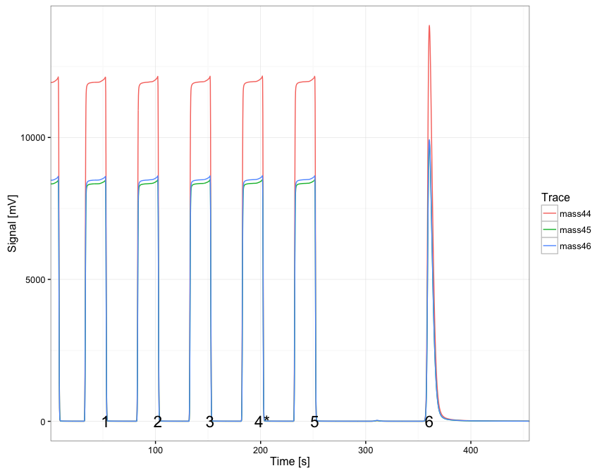

```r
iso_files[["MAT25392080_P02E_run02_Conditioner-0000.dxf"]]$make_ggplot()
```

### Data processing step 1 (first look)

In the first step, we pull out the data tables from the raw data, parse the file names to put the different files into different categories, pull out only the N2O peak (no need for the references) and focus on the main columns we are interested in. Everything is chained together with the pipe `%>%` operator for better readability. Info messages form each function will provide feedback on what happened at each step.

```r
df.raw <- iso_files %>%
  # pull out the data summary from the raw isodat file:
  get_isodat_data_tables() %>%
  # derive file categories:
  parse_file_names() %>%
  # discard the reference peaks:
  select_N2O_peak(360) %>%
  # focus on the columns we care about:
  rename(d45 = `d 45N2O/44N2O`, d46 = `d 46N2O/44N2O`, area = `Intensity All`) %>%
  # first round of weeding out columns:
  select_columns(folder, date, analysis, run_number, category, name, volume, area, d45, d46)
```

```
## INFO: Isodat data tables from 185 files with a total number of 1108 peaks successfully aggregated.
```

```
## INFO: Parsed 1108 file names into new columns for analysis 'name', 'category' and 'run_number'.
##       Found categories P02E (564x), IAEA-NO3 (168x), USGS-34 (168x), N2O (138x), DPR (36x), Background (12x), LNSW (11x), Conditioner (6x), NO (5x)
```

```
## INFO: 183 N2O peaks found (at retention time 360s), 925 other peaks discarded.
```

```
## INFO: Selecting 10 columns (folder, date, analysis, run_number, category, name, volume, area, d45, d46), discarding 35 (file, Component, Start, Rt, End, Ampl 44, Ampl 45, Ampl 46, Nr., rIntensity 44, rIntensity 45, rIntensity 46, rIntensity All, Intensity 44, Intensity 45, Intensity 46, rR 45N2O/…
```

Now to get a sense for what the data looks like, let’s look at the first couple of rows and throw them in a table (`kable`). To look at the complete data frame, you can always call `View(df.raw)` or double click on the name in the *Environmen* tab on the upper right.

```r
df.raw %>% head(n=5) %>% kable()
```

| folder | date | analysis | run_number | category | name | volume | area | d45 | d46 |
| --- | --- | --- | --- | --- | --- | --- | --- | --- | --- |
| test_run | 2015-03-03 12:55:04 | 92080 | 1 | Conditioner | Conditioner |  | 80.65752 | 0.6003229 | -0.8004934 |
| test_run | 2015-03-03 13:04:44 | 92081 | 2 | N2O | N2O | 20nmol | 82.40901 | 0.5509991 | -0.9316094 |
| test_run | 2015-03-03 13:14:22 | 92082 | 3 | N2O | N2O | 20nmol | 81.97664 | 0.5639691 | -0.9384240 |
| test_run | 2015-03-03 13:24:00 | 92083 | 4 | N2O | N2O | 20nmol | 82.40488 | 0.5609545 | -0.9058410 |
| test_run | 2015-03-03 13:33:38 | 92084 | 5 | N2O | N2O | 20nmol | 81.98561 | 0.5785008 | -0.9329287 |

Additinally, `isorunN2O` provides a couple more convience functions for inspecting the data (together with the very helpful function `group_by` from the `dplyr` package). As table use `?generate_data_table` (see help for details):

```r
df.raw %>% group_by(folder, category) %>% generate_data_table(area, d45, d46)  %>% kable()
```

| folder | category | n | area.avg | area.sd | d45.avg | d45.sd | d46.avg | d46.sd |
| --- | --- | --- | --- | --- | --- | --- | --- | --- |
| test_run | P02E | 94 | 87.1925131 | 1.1439070 | 6.1176044 | 0.5982852 | -2.7215962 | 0.5012561 |
| test_run | IAEA-NO3 | 28 | 86.3229634 | 1.2347195 | 5.3311431 | 0.1064835 | 19.1541208 | 0.2589260 |
| test_run | USGS-34 | 28 | 86.4001330 | 1.2574264 | -2.1204132 | 0.0481770 | -31.8621068 | 0.1768753 |
| test_run | N2O | 23 | 81.7609708 | 1.8756106 | 0.6390149 | 0.0648109 | -0.7990613 | 0.1078678 |
| test_run | DPR | 6 | 90.0835241 | 1.4504975 | 5.3623376 | 0.0496230 | -3.1140484 | 0.1894474 |
| test_run | Background | 2 | 0.2558576 | 0.0002725 | 11.8768058 | 0.5723399 | -1.1343584 | 1.3324915 |
| test_run | Conditioner | 1 | 80.6575200 | NA | 0.6003229 | NA | -0.8004934 | NA |
| test_run | LNSW | 1 | 0.3274756 | NA | 14.2428599 | NA | 12.4141439 | NA |

and visually with `?plot_overview`, which generates a [`ggplot`](http://ggplot2.org/):

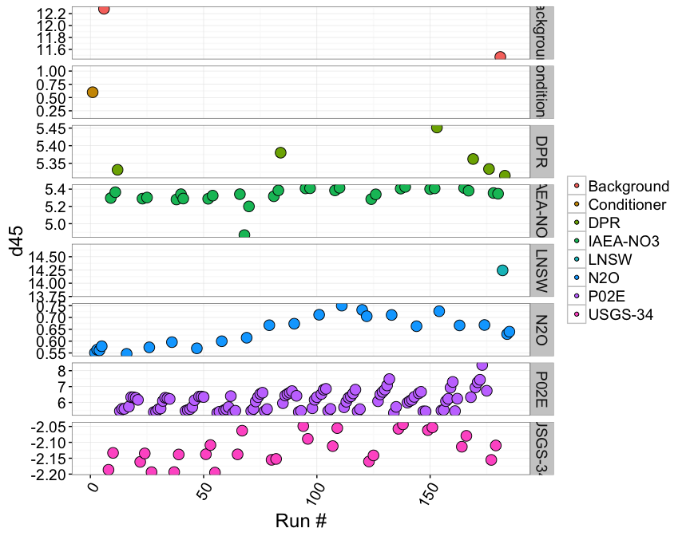

```r
df.raw %>% plot_overview(d45)
```

or a little bit more elaborate specifiying in more detail how to color and panel the overview plot:

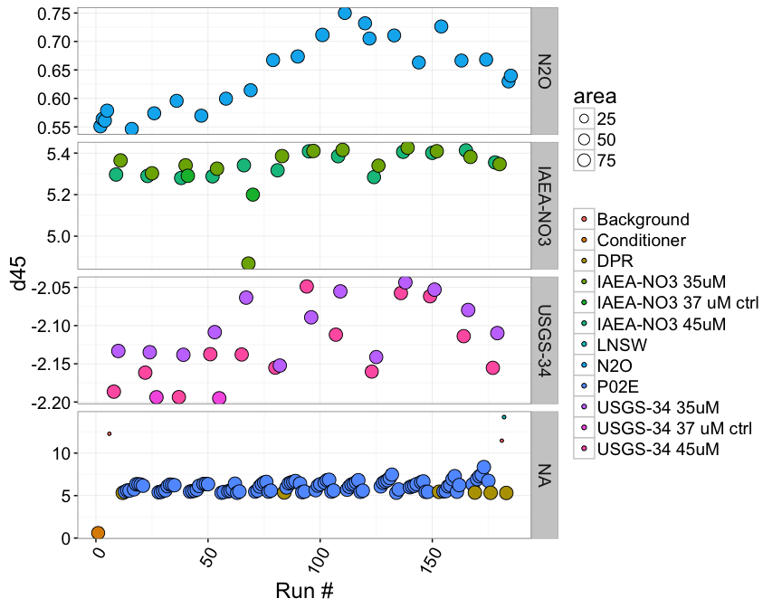

```r
df.raw %>% plot_overview(
  d45, size = area,
  color = ifelse(category %in% c("IAEA-NO3", "USGS-34"), name, category),
  panel = factor(category, levels = c("N2O", "IAEA-NO3", "USGS-34")))
```

or as an interactive plot (mouse-over information and zooming), which is a little easier for data exploration (requires the library `plotly` to render correctly in RMarkdown):

```r
ggplot2::last_plot() %>% make_interactive()
```

[interactive chart not shown]

### Data processing step 2 (continued)

From the first look it is clear that there are couple of things we need to consider, there is one sample that was marked as questionable during injection (#68) which we’d like to exclude for now, there were also a couple of samples that were controls rather than standards and should go into their own category, and while we’re at it we’ll also identify the blanks. Lastly, it appears there is some drift so we will want to evaluate that.

#### Categories

```r
df.cat <- df.raw %>%
  change_category(name %in% c("IAEA-NO3 37 uM ctrl", "USGS-34 37 uM ctrl"), "control") %>%
  change_category(run_number == 68, "excluded") %>%
  change_category(name == "LNSW Blank", "blank")
```

```
## INFO: the category of 4 analyses was changed to 'control' (by applying criteria 'name %in% c("IAEA-NO3 37 uM ctrl", "USGS-34 37 uM ctrl")')
```

```
## INFO: the category of 1 analyses was changed to 'excluded' (by applying criteria 'run_number == 68')
```

```
## INFO: the category of 1 analyses was changed to 'blank' (by applying criteria 'name == "LNSW Blank"')
```

#### Drift correction

The `evaluate_drift` function provides a number of different strategies for evaluating drift using different correction methods, here we’re trying a polynomial fit (`method = "loess"`) and are correcting with the standards as well as N2O. We also want to see a summary plot of the drift using `plot = TRUE` (the default), which will plot the drift polynomials on top of the original data (normalized to average isotope values in each group) and the residuals after applying the correction. For details look at the `?evaluate_drift` help. The drift correction stores the drift corrected values in `d45.cor` and `d46.cor`.

```
## INFO: 183 N2O analyses drift corrected (new data columns 'd45.cor' & 'd46.cor', and parameter 'p.drift' added)
##       Used the 'loess' method with included categories 'N2O, USGS-34, IAEA-NO3'.
##       Residual sum of squares: 0.280 (d45), 0.720 (d46)
##       Standard deviations in d45/d46 before and after drift correction, by groupings:
##       Before: 0.04/0.14 (IAEA-NO3 35uM), 0.05/0.14 (IAEA-NO3 45uM), 0.06/0.11 (N2O), 0.04/0.08 (USGS-34 35uM), 0.05/0.17 (USGS-34 45uM)
##       After: 0.03/0.11 (IAEA-NO3 35uM), 0.04/0.11 (IAEA-NO3 45uM), 0.03/0.03 (N2O), 0.04/0.07 (USGS-34 35uM), 0.03/0.12 (USGS-34 45uM)
```

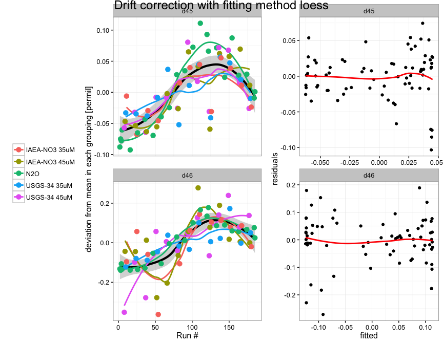

```r
df.drift <- df.cat %>%
  evaluate_drift(d45, d46, correct = TRUE, plot = TRUE,
                correct_with = category %in% c("USGS-34", "IAEA-NO3", "N2O"),
                method = "loess")
```

Let’s take a quick look how we’re doing after drift correction:

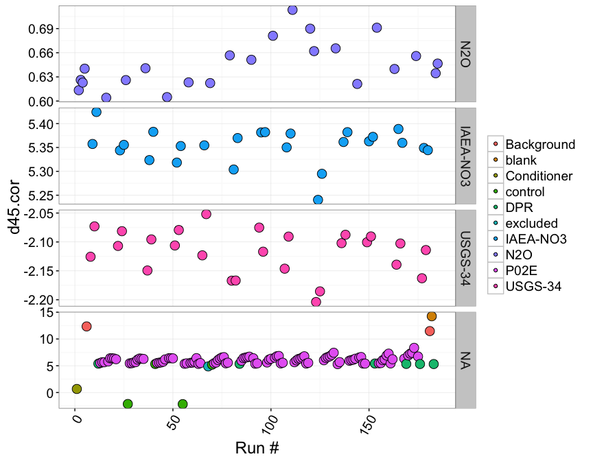

```r
df.drift %>% plot_overview(d45.cor, panel = factor(category, levels = c("N2O", "IAEA-NO3", "USGS-34")))
```

### Data processing step 3 (continued)

Now that we’re drift corrected, time to switch to $\delta^{15}N$ and $\delta^{18}O$ space and calibrate against our standards.

#### O17 correction

We’re doing the O17 correction here (instead of before the drift) but it is a matter of discussion whether drift correction or O17 correction should be applied first. The O17 correction introduces new columns `d15.raw` and `d18.raw`.

```r
df.O17 <- df.drift %>%
  correct_N2O_for_17O(d45.cor, d46.cor) %>%
  select_columns(-d45, -d45.cor, -d46, -d46.cor) # no longer needd, remove these columns
```

```
## INFO: 183 N2O analyses were corrected for 17O (new columns 'd15.raw' and 'd18.raw' added).
##       Correction effects: mean d45 = 4.099 with resulting d15 = 4.409, mean d46 = -3.495 with resulting d18 = -3.586 [permil]
##       Correction term constants: k46 = 1.0081, k45 = -0.0157, k17 = -0.0006, k45x45 = -0.0075, k45x17 = -0.0007, k17x17 = 0.0001
```

```
## INFO: Selecting 11 columns (folder, date, analysis, run_number, category, name, volume, area, p.drift, d15.raw, d18.raw), discarding 4 (d45, d46, d45.cor, d46.cor).
```

#### Calibration

Last steps are collecting some additional information e.g. the background (see `?calculate_background`), calculating concentrations (see `?calculate_concentrations`) and then calibrating $\delta^{15}N$ and $\delta^{18}O$ (see `?calibrate_d15` and `?calibrate_d18`).

```r
df.cal <- df.O17 %>%
  calculate_background(area) %>%
  calculate_concentrations(area, volume) %>%
  calibrate_d15(d15.raw) %>%
  calibrate_d18(d18.raw, cell_volume = 1.5)
```

```
## INFO: the category of 2 analyses was changed to 'background' (by applying criteria 'name %in% c("background", "Background")')
```

```
## INFO: background area calculated and stored in new parameter column 'p.bgrd': 0.256
```

```
## INFO: NOx concentrations and injection amounts (new columns 'conc' and 'amount') calculated from 35uM (25x) & 45uM (26x) standards
##       Parameter columns mass spec signal 'p.yield' (4.346) and effective 'p.run_size' (19.8, 19.9nmol) added.
```

```
## INFO: d15 values calibrated (new columm 'd15.cal') using USGS-34 (-1.8) & IAEA-NO3 (4.7) --> stored in 'p.d15_stds'
##       Parameter columns for calibration slope (true/measured) 'p.d15_m' (1.004) and intercept 'p.d15_b' (-0.436) added.
```

```
## INFO: d18 values calibrated (new columm 'd18.cal') using USGS-34 (-27.93) & IAEA-NO3 (25.61) --> stored in 'p.d18_stds'
##       Effective concentration dependence of calibration regressions taken into account.
##       Parameter columns for calibration slopes (true/measured) 'p.d18_m' (1.0402, 1.0449) and intercepts 'p.d18_b' (5.5736, 5.4573) added.
```

### Summary

At the end of the data processing, a couple of ways to summarize the data, including the `generate_data_table` introduced earlier (here used to compare the raw vs. calibrated values with different groupings), but also `generate_parameter_table`, which summarizes all the parameters recorded from the data processing calls:

```r
df.cal %>% group_by(category) %>% generate_data_table(cutoff = 3, d15.raw, d15.cal, d18.raw, d18.cal) %>% kable()
```

| category | n | d15.raw.avg | d15.raw.sd | d15.cal.avg | d15.cal.sd | d18.raw.avg | d18.raw.sd | d18.cal.avg | d18.cal.sd |
| --- | --- | --- | --- | --- | --- | --- | --- | --- | --- |
| P02E | 94 | 6.5044991 | 0.6072631 | 6.0956796 | 0.6098144 | -2.845659 | 0.4768841 | 2.597172 | 0.5132681 |
| USGS-34 | 26 | -1.3581482 | 0.0376199 | -1.8000000 | 0.0377780 | -32.081713 | 0.1617086 | -27.927056 | 0.1307778 |
| IAEA-NO3 | 25 | 5.1146585 | 0.0380937 | 4.7000000 | 0.0382537 | 19.274543 | 0.1063017 | 25.610681 | 0.1103222 |
| N2O | 23 | 0.6998517 | 0.0301474 | 0.2666459 | 0.0302740 | -0.805518 | 0.0345544 | NaN | NaN |
| DPR | 6 | 5.7230744 | 0.0368411 | 5.3109720 | 0.0369958 | -3.241075 | 0.1830612 | 2.209375 | 0.2024761 |
| control | 4 | 1.8147404 | 3.7141761 | 1.3862185 | 3.7297799 | -6.442986 | 29.4643097 | -1.227201 | 30.7280199 |

```r
df.cal %>% group_by(category, name) %>% generate_data_table(cutoff = 3, d15.raw, d15.cal, d18.raw, d18.cal) %>% kable()
```

| category | name | n | d15.raw.avg | d15.raw.sd | d15.cal.avg | d15.cal.sd | d18.raw.avg | d18.raw.sd | d18.cal.avg | d18.cal.sd |
| --- | --- | --- | --- | --- | --- | --- | --- | --- | --- | --- |
| DPR | DPR | 6 | 5.7230744 | 0.0368411 | 5.3109720 | 0.0369958 | -3.241075 | 0.1830612 | 2.209375 | 0.2024761 |
| IAEA-NO3 | IAEA-NO3 45uM | 13 | 5.1021287 | 0.0402743 | 4.6874176 | 0.0404435 | 19.262639 | 0.1082368 | 25.609827 | 0.1135329 |
| IAEA-NO3 | IAEA-NO3 35uM | 12 | 5.1282324 | 0.0317818 | 4.7136309 | 0.0319153 | 19.287438 | 0.1073573 | 25.611606 | 0.1117657 |
| N2O | N2O | 23 | 0.6998517 | 0.0301474 | 0.2666459 | 0.0302740 | -0.805518 | 0.0345544 | NaN | NaN |
| USGS-34 | USGS-34 35uM | 13 | -1.3465865 | 0.0377268 | -1.7883897 | 0.0378853 | -31.953691 | 0.0672862 | -27.903607 | 0.1081278 |
| USGS-34 | USGS-34 45uM | 13 | -1.3697100 | 0.0351499 | -1.8116103 | 0.0352976 | -32.209734 | 0.1201678 | -27.950506 | 0.1508238 |

```r
df.cal %>% generate_parameter_table() %>% kable()
```

| p.drift | p.bgrd | p.run_size | p.yield | p.d15_stds | p.d15_m | p.d15_b | p.d18_stds | p.d18_m | p.d18_b |
| --- | --- | --- | --- | --- | --- | --- | --- | --- | --- |
| loess: N2O, USGS-34, IAEA-NO3 | 0.2558576 | 19.8 | 4.345999 | USGS-34 (-1.8) & IAEA-NO3 (4.7) | 1.004201 | -0.436146 | USGS-34 (-27.93) & IAEA-NO3 (25.61) | 1.0402, 1.0449 | 5.5736, 5.4573 |
| loess: N2O, USGS-34, IAEA-NO3 | 0.2558576 | 19.9 | 4.345999 | USGS-34 (-1.8) & IAEA-NO3 (4.7) | 1.004201 | -0.436146 | USGS-34 (-27.93) & IAEA-NO3 (25.61) | 1.0402, 1.0449 | 5.5736, 5.4573 |

And of course visually in an interactive plot with additional mouseoverinfo (`text = make_itext...`):

```r
df.cal %>% plot_overview(
  d15.cal,
  text = make_itext(name, d15 = round(d15.cal, 2), d18 = round(d18.cal, 2), amount = round(amount,3)),
  color = ifelse(category %in% c("IAEA-NO3", "USGS-34"), name, category),
  panel = factor(category, levels = c("N2O", "IAEA-NO3", "USGS-34"))) %>%
  make_interactive()
```

[interactive chart not shown]

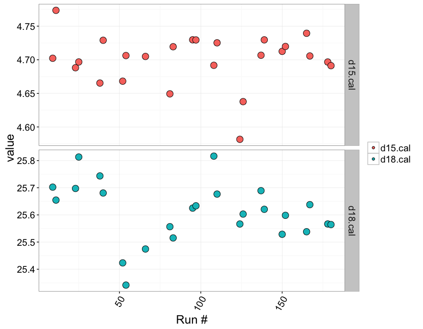

```r
df.cal %>% filter(category == "IAEA-NO3") %>%
  plot_overview(d15.cal, d18.cal, color = panel)
```

```r
df.cal %>% filter(category %in% c("P02E", "DPR")) %>%
  plot_overview(d15.cal, d18.cal, color = paste(category, panel)) %>% make_interactive()
```

[interactive chart not shown]

### Export data

At any point during the process, if you like to export data as excel, this is easy with the `openxlsx` package (here using a couple of filter options in `select` to skip parameters and raw values, and using `arrange` to sort the data):

```r
if (!requireNamespace("openxlsx", quietly = TRUE)) install.packages("openxlsx")
df.cal %>%
  select(-starts_with("p."), -ends_with(".raw"), -ends_with(".cor"), d15 = d15.cal, d18 = d18.cal) %>%
  arrange(category, name) %>%
  openxlsx::write.xlsx(file = "data_reduction_example.xlsx")
```